[figure not shown]

MBA EM JORNALISMO DE DADOS  
Web scraping com Python  
Rodolfo Viana

# AULA 2 — REQUESTS E BEAUTIFUL SOUP

Nesta aula veremos:

1. Requests
1. Funções comuns
2. Beautiful Soup
1. Funções comuns
3. Código limpo

# Requests

Agora que vimos o que *web scraping* no contexto do jornalismo e entendemos a estrutura de um site como uma coleção de tags de HTML e atributos de CSS, podemos partir para a prática.

E a prática começa com **Requests**, uma biblioteca externa bastante popular para lidar com o trânsito de *request* e *response*.

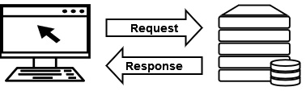

É **Requests** que vai até o servidor onde o site está hospedado, pega o conteúdo e traz para o Python. E ele faz isso de maneira bastante intuitiva. E a primeira coisa que precisamos é importar a biblioteca.

```python
import requests
```

### Funções comuns

Com a biblioteca importada no script, podemos começar o trânsito de dados. Por exemplo, vamos supor que queremos importar o conteúdo do site do fictício Ministério dos Riachos Brasileiros que vimos na aula passada, e cujo link é http://rodolfoviana.com.br/idp/webscraping/agenda.html.

```python
# Vamos salvar a url na variável `site`
site = 'http://rodolfoviana.com.br/idp/webscraping/agenda.html'

# A função `requests.get(url)` traz os dados para nosso script,
# mais especificamente para a variável `dados`
dados = requests.get(site)
```

As poucas linhas de código acima bastam para meu script ir até o site e baixar todo o conteúdo. Agora eu tenho o site todo salvo em `dados`. Com outras funções de **Requests** podemos ver o que temos na variável.

```python
# `status_code` mostra o status HTTP.
# 200 significa que a página existe e a conexão foi bem-sucedida.
# 401, que você não é autorizado a acessá-lo.
# 404, que não existe.
# Veja todos os códigos em https://developer.mozilla.org/pt-BR/docs/Web/HTTP/Status
print(dados.status_code)
```

```
200
```

```python
# `headers` mostra os metadados que integram o
# cabeçalho do site, como a última vez que o site
# foi modificado, o nome do servidor etc.
print(dados.headers)
```

```
{'Connection': 'keep-alive', 'Content-Length': '1348', 'Server': 'GitHub.com', 'Content-Type': 'text/html; charset=utf-8', 'Last-Modified': 'Tue, 09 May 2023 22:57:18 GMT', 'Access-Control-Allow-Origin': '*', 'ETag': 'W/"645acfce-1790"', 'expires': 'Tue, 09 May 2023 23:08:40 GMT', 'Cache-Control': '…
```

```python
# `content` e `text` trazem o conteúdo do site,
# sendo `content` para ver o conteúdo em bytes
# e `text` para ver o conteúdo em unicode
# (como normalmente lemos)
print(dados.content)
```

```
b'<!doctype html>\n<html lang="pt-br">\n\n<head>\n    <meta charset="utf-8">\n    <meta name="viewport" content="width=device-width, initial-scale=1">\n    <title>Minist\xc3\xa9rio dos Riachos Brasileiros | Agenda</title>\n    <link href="https://cdn.jsdelivr.net/npm/bootstrap@5.2.3/dist/css/bootstr…
```

```python
print(dados.text)
```

```
<!doctype html>
<html lang="pt-br">

<head>
    <meta charset="utf-8">
    <meta name="viewport" content="width=device-width, initial-scale=1">
    <title>Ministério dos Riachos Brasileiros | Agenda</title>
    <link href="https://cdn.jsdelivr.net/npm/bootstrap@5.2.3/dist/css/bootstrap.min.css" rel="stylesheet"
        integrity="sha384-rbsA2VBKQhggwzxH7pPCaAqO46MgnOM80zW1RWuH61DGLwZJEdK2Kadq2F9CUG65" crossorigin="anonymous">
</head>

<body>
    <nav class="navbar bg-light">
        <div class="container">
            <a class="navbar-brand" href="#">
                <img src="https://upload.wikimedia.org/wikipedia/commons/thumb/9/91/Libra_logo_icon.svg/246px-Libra_logo_icon.svg.png"
                    alt="MRB" width="30" height="30" class="d-inline-block align-text-center">
                <span class="mx-2">Ministério dos Riachos Brasileiros</span>
            </a>
        </div>
    </nav>
    <h1 class="display-1 my-5 text-center">Agenda do Ministro</h1>

    <div class="container">
        <div class="card mb-3 text-bg-secondary">
            <div class="card-body">
                <h5 class="card-title">Entrevista para a CBN</h5>
                <p class="card-text">Imprensa</p>
            </div>
            <ul class="list-group list-group-flush">
                <li class="list-group-item">Gabinete do ministro</li>
                <li class="list-group-item">12 de maio de 2023</li>
                <li class="list-group-item">08:30</li>
            </ul>
        </div>
        <div class="card mb-3 text-bg-secondary">
            <div class="card-body">
                <h5 class="card-title">Reunião com secretários</h5>
                <p class="card-text">Expediente</p>
            </div>
```

[output cut: 76 more lines]

```
                        <li class="mb-2"><a href="#">Início</a></li>
                        <li class="mb-2"><a href="#">Contato</a></li>
                        <li class="mb-2"><a href="#">Dados abertos</a></li>
                        <li class="mb-2"><a href="#">Resoluções</a></li>
                    </ul>
                </div>
            </div>
        </div>
    </footer>
    <script src="https://cdn.jsdelivr.net/npm/bootstrap@5.2.3/dist/js/bootstrap.bundle.min.js"
        integrity="sha384-kenU1KFdBIe4zVF0s0G1M5b4hcpxyD9F7jL+jjXkk+Q2h455rYXK/7HAuoJl+0I4"
        crossorigin="anonymous"></script>
</body>

</html>
```

Observe que `text` traz o código-fonte inteiro do site! É essa nossa matéria-prima numa raspagem de dados; portanto, vamos salvar numa variável para uso posterior.

```python
codigo = dados.text
```

# Beautiful Soup

Agora que temos o código-fonte salvo na variável `codigo`, o passo seguinte é interpretar esse código, é "quebrar" cada tag de HTML e atributo de CSS para, enfim, encontrar os dados que desejamos. É aí que entra **Beautiful Soup**. Seu papel é reconhecer os elementos do código.

Vamos importar essa biblioteca.

```python
from bs4 import BeautifulSoup as bs
# Reparem no trecho `as bs`. Significa que dei
# à biblioteca o apelido de `bs` para não ter
# de ficar digitando `BeautifulSoup` sempre
# que eu precisar usá-la
```

### Funções comuns

Com **Beautiful Soup** importado, preciso antes de tudo passar o conteúdo de `codigo` para que a biblioteca interprete.

```python
# Ao chamar `BeautifulSoup()`, tenho dois argumentos:
# 1. o primeiro é o que eu quero interpretar (no caso,
# o que está contido na variável `codigo`)
# 2. o segundo é o método para fazer a interpretação
# (no caso, `html.parser`, o interpretador mais
# básico de Beautiful Soup. Há outros, mas por ora
# vamos nos manter com este.)
cod_parseado = bs(codigo, 'html.parser')
```

Agora que `codigo` está interpretado e salvo na variável `cod_parseado`, temos todas as tags de HTML e atributos de CSS reconhecidos. Veja alguns exemplos:

```python
# `title` traz o título da página
print(cod_parseado.title)
```

```
<title>Ministério dos Riachos Brasileiros | Agenda</title>
```

```python
# `nav` traz tudo o que estiver contido na tag `nav`
print(cod_parseado.nav)
```

```
<nav class="navbar bg-light">
<div class="container">
<a class="navbar-brand" href="#">
<img alt="MRB" class="d-inline-block align-text-center" height="30" src="https://upload.wikimedia.org/wikipedia/commons/thumb/9/91/Libra_logo_icon.svg/246px-Libra_logo_icon.svg.png" width="30"/>
<span class="mx-2">Ministério dos Riachos Brasileiros</span>
</a>
</div>
</nav>
```

```python
# `h1` traz a tag `h1`
print(cod_parseado.h1)
```

```
<h1 class="display-1 my-5 text-center">Agenda do Ministro</h1>
```

Olhando o código-fonte, porém, notamos que as informações que buscamos estão dentro de `div.card` (ou seja, tag `div` com a classe `card`). E que há diversos `div.card`.

Há funções de **Beautiful Soup** que capturam as diversas menções a elementos.

```python
# Aqui, `find_all()` tem dois argumentos:
# 1. a tag de HTML,
# 2. a classe de CSS referente à tag de HTML
# que queremos.
# Com isso, não pegamos todos os `div`, mas
# somente aqueles com `card` como classe.
divs = cod_parseado.find_all('div', class_='card')

# O resultado de `find_all()` é uma lista
# com os elementos -- neste caso, sete
# elementos; sete `div` com a classe `card`
print(len(divs))
print(divs)
```

```
7
[<div class="card mb-3 text-bg-secondary">
<div class="card-body">
<h5 class="card-title">Entrevista para a CBN</h5>
<p class="card-text">Imprensa</p>
</div>
<ul class="list-group list-group-flush">
<li class="list-group-item">Gabinete do ministro</li>
<li class="list-group-item">12 de maio de 2023</li>
<li class="list-group-item">08:30</li>
</ul>
</div>, <div class="card mb-3 text-bg-secondary">
<div class="card-body">
<h5 class="card-title">Reunião com secretários</h5>
<p class="card-text">Expediente</p>
</div>
<ul class="list-group list-group-flush">
<li class="list-group-item">Gabinete do ministro</li>
<li class="list-group-item">12 de maio de 2023</li>
<li class="list-group-item">09:30</li>
</ul>
</div>, <div class="card mb-3 text-bg-secondary">
<div class="card-body">
<h5 class="card-title">Visita à comunidade do Riacho Branco</h5>
<p class="card-text">Evento público</p>
</div>
<ul class="list-group list-group-flush">
<li class="list-group-item">Sede da ATRB</li>
<li class="list-group-item">12 de maio de 2023</li>
<li class="list-group-item">11:00</li>
</ul>
</div>, <div class="card mb-3 text-bg-secondary">
<div class="card-body">
<h5 class="card-title">Viagem a Belém - PA</h5>
<p class="card-text">Expediente</p>
</div>
<ul class="list-group list-group-flush">
<li class="list-group-item"> </li>
<li class="list-group-item">12 de maio de 2023</li>
<li class="list-group-item">13:00</li>
```

[output cut: 17 more lines]

```
<li class="list-group-item"> </li>
<li class="list-group-item">12 de maio de 2023</li>
<li class="list-group-item">17:00</li>
</ul>
</div>, <div class="card mb-3 text-bg-secondary">
<div class="card-body">
<h5 class="card-title">Entrevista à TV Senado</h5>
<p class="card-text">Imprensa</p>
</div>
<ul class="list-group list-group-flush">
<li class="list-group-item">Sede da TV Senado</li>
<li class="list-group-item">12 de maio de 2023</li>
<li class="list-group-item">18:30</li>
</ul>
</div>]
```

Agora que temos os elementos que queremos separados numa lista, podemos selecionar o que queremos exatamente com `for-loop`.

```python
for i in divs:
    # `text` pega somente o texto contido na tag, e não toda a tag
    evento = i.h5.text
    local = i.find_all('li')[0].text
    data = i.find_all('li')[1].text
    horario = i.find_all('li')[2].text

    print(f"Evento: {evento}")
    print(f"Local: {local}")
    print(f"Data: {data}")
    print(f"Horário: {horario}\n") # \n dá quebra de linha a mais
```

```
Evento: Entrevista para a CBN
Local: Gabinete do ministro
Data: 12 de maio de 2023
Horário: 08:30

Evento: Reunião com secretários
Local: Gabinete do ministro
Data: 12 de maio de 2023
Horário: 09:30

Evento: Visita à comunidade do Riacho Branco
Local: Sede da ATRB
Data: 12 de maio de 2023
Horário: 11:00

Evento: Viagem a Belém - PA
Local:
Data: 12 de maio de 2023
Horário: 13:00

Evento: Reunião com pescadores
Local: Cooperativa de Pesca do Belém do Pará
Data: 12 de maio de 2023
Horário: 15:00

Evento: Retorno a Brasília
Local:
Data: 12 de maio de 2023
Horário: 17:00

Evento: Entrevista à TV Senado
Local: Sede da TV Senado
Data: 12 de maio de 2023
Horário: 18:30
```

Para nós, porém, não é interessante imprimir na tela com `print()`, mas sim salvar numa lista de dicionários para, porteriormente, trabalhar com Pandas.

```python
lista_eventos = list()
for i in divs:
    compromisso = {
        'evento': i.h5.text,
        'local': i.find_all('li')[0].text,
        'data': i.find_all('li')[1].text,
        'horario': i.find_all('li')[2].text
    }
    lista_eventos.append(compromisso)

print(lista_eventos)
```

```
[{'evento': 'Entrevista para a CBN', 'local': 'Gabinete do ministro', 'data': '12 de maio de 2023', 'horario': '08:30'}, {'evento': 'Reunião com secretários', 'local': 'Gabinete do ministro', 'data': '12 de maio de 2023', 'horario': '09:30'}, {'evento': 'Visita à comunidade do Riacho Branco', 'local…
```

Agora, sim, podemos usar Pandas e começar nossas análises.

```python
import pandas as pd

df = pd.DataFrame(lista_eventos)
df
```

|  | evento | local | data | horario |
| --- | --- | --- | --- | --- |
| 0 | Entrevista para a CBN | Gabinete do ministro | 12 de maio de 2023 | 08:30 |
| 1 | Reunião com secretários | Gabinete do ministro | 12 de maio de 2023 | 09:30 |
| 2 | Visita à comunidade do Riacho Branco | Sede da ATRB | 12 de maio de 2023 | 11:00 |
| 3 | Viagem a Belém - PA |  | 12 de maio de 2023 | 13:00 |
| 4 | Reunião com pescadores | Cooperativa de Pesca do Belém do Pará | 12 de maio de 2023 | 15:00 |
| 5 | Retorno a Brasília |  | 12 de maio de 2023 | 17:00 |
| 6 | Entrevista à TV Senado | Sede da TV Senado | 12 de maio de 2023 | 18:30 |

# Código limpo

Em suma, portanto, temos o seguinte script — limpo de anotações e demais explicações:

```python
import requests
from bs4 import BeautifulSoup as bs
import pandas

site = 'http://rodolfoviana.com.br/idp/webscraping/agenda.html'
dados = requests.get(site)
codigo = dados.text
cod_parseado = bs(codigo, 'html.parser')
divs = cod_parseado.find_all('div', class_='card')
lista_eventos = list()
for i in divs:
    compromisso = {
        'evento': i.h5.text,
        'local': i.find_all('li')[0].text,
        'data': i.find_all('li')[1].text,
        'horario': i.find_all('li')[2].text
    }
    lista_eventos.append(compromisso)
df = pd.DataFrame(lista_eventos)
df
```

|  | evento | local | data | horario |
| --- | --- | --- | --- | --- |
| 0 | Entrevista para a CBN | Gabinete do ministro | 12 de maio de 2023 | 08:30 |
| 1 | Reunião com secretários | Gabinete do ministro | 12 de maio de 2023 | 09:30 |
| 2 | Visita à comunidade do Riacho Branco | Sede da ATRB | 12 de maio de 2023 | 11:00 |
| 3 | Viagem a Belém - PA |  | 12 de maio de 2023 | 13:00 |
| 4 | Reunião com pescadores | Cooperativa de Pesca do Belém do Pará | 12 de maio de 2023 | 15:00 |
| 5 | Retorno a Brasília |  | 12 de maio de 2023 | 17:00 |
| 6 | Entrevista à TV Senado | Sede da TV Senado | 12 de maio de 2023 | 18:30 |

**Mais sobre os tópicos da aula**

- Vídeos
  - [Introdução ao BeautifulSoup - Raspagem de Dados com Python](https://www.youtube.com/watch?v=WzUPnQwSQyk), em Hashtag Programação
  - [Python Tutorial: Web Scraping with BeautifulSoup and Requests](https://www.youtube.com/watch?v=ng2o98k983k), em Corey Schafer [inglês]
  - [Webscraping com Beautiful Soup](https://www.youtube.com/watch?v=aNtzKGTujuA), em Let's Data
- Leituras
  - [Documentação de Requests](https://requests.readthedocs.io/en/latest/) [inglês]
  - [Documentação de Beautiful Soup](https://www.crummy.com/software/BeautifulSoup/bs4/doc/index.html) [inglês]

**Atividade**

O site do IMDb traz a lista dos melhores filmes brasileiros, segundo votação popular. A URL é esta: https://www.imdb.com/list/ls060310079/?sort=user_rating,desc&st_dt=&mode=detail&page=1.

Há diversas informações ali, como nome do filme, ano de lançamento, a nota, a sinopse etc. São mais de 90 filmes.

Crie um script para obter o máximo de informação possível e salve os dados num dataframe de Pandas.